# Active Portfolio Management - Final Project

# Problem 2 : REINFORCE with BASELINE

##### Team member:

- Daniel Molson - DM4942: Problem 1 model setup & report
- Peter Young - PTY2004: Problem 1 model setup & report
- Supavitch Nakburee - SN3049: Problem 2 model setup & param tunnings
- Thumthiti Pinto - TP2137: Problem 2 model setup & report

##### This project consists of 3 notebooks:

1. FinalProject_Problem1_REINFORCE.ipynb
2. FinalProject_Problem2_REINFORCE_with_BASELINE.ipynb
3. FinalProject_REINFORCEwithBaseline_Tuning.ipynb (This notebook)

```python
import time
import numpy as np
import pandas as pd
from scipy.stats import norm
import random
import matplotlib.pyplot as plt
import sys
import time
```

```python
train_pd = pd.read_csv("train_data", delimiter='|')
train_np = np.array(train_pd)

test_pd = pd.read_csv("test_data", delimiter='|')
test_np = np.array(test_pd)
```

# This project consists of three notebooks

# Problem 2: REINFORCE with Baseline tunning process

- We used the same code from REINFORCE with Baseline
- We use params specified as follow since the baseline function is quite sensitive:
  - batch_size: 1
  - total_updates: 50000
  - initial learning rate of theta = 0.001
  - initial learning rate of linear = 0.00001
  - decay rate of linear is tuned for [0.01,0.1]

```python
# helper functions - not necessarily being used in training

def d1(S, K, sigma, tau):
    return (np.log(S/K) + 1/2 * tau * (sigma)**2) / (sigma * np.sqrt(tau))

def BS(S, K, sigma, tau):
    if tau != 0:
        return S*norm.cdf(d1(S, K, sigma, tau)) - K * norm.cdf(d1(S, K, sigma, tau)) - 1/2 * sigma * np.sqrt(tau)
    else:
        return max(S - K, 0)

def sigmoid(x):
    return 1/(1 + np.exp(-x))

def sigmoid_grad(x):
    return np.exp(-x)/(1 + np.exp(-x))**2

def my_log(x):
    if x <= 0.1:
        return x - 1 # approx log(x) for small x
    else:
        return np.log(x)
```

```python
class policy:
    '''This class holds methods relevant for the policy function'''
    def __init__(self, possible_actions, theta, K):
        self.min_total = -100 # min total position
        self.max_total = 0 # max total position

        self.actions = possible_actions #[-100,100]
        self.K = K
        self.theta = theta

    def get_theta(self):
        return self.theta

    def set_theta(self, theta):
        self.theta = theta

    def get_pref(self, S_t, tau, n, C_t):
        '''calculate perference function'''
        x = ( (self.actions + n)/100 + C_t/S_t )**2 # -x is maximized when new_action + current_position = 100*C_t/S_t

        # delta*S + C = 0
        # delta = -C/S

        # print statements for debugging
        #print('S_t', S_t)
        #print('C_t', C_t)
        #print('x', x)
        #print('mu', mu)
        #print('sd', sd)

        pref = -(1000/np.abs(self.theta))*x # theta acts like a std dev for our pref function
        return pref

    def get_prob(self, S_t, tau, n, C_t):
        '''calculate probability function: softmax of preference function'''
        pref = self.get_pref(S_t, tau, n, C_t)
        bounds = (self.actions + n >= self.min_total)*(self.actions + n <= self.max_total) # exclude actions that exceed position limit
        prob = np.exp(pref)*bounds
        return prob/np.sum(prob)

    def get_pref_grad(self, S_t, tau, n, C_t):
        '''calculate gradient of preference function'''
        x = ( (self.actions + n)/100 - C_t/S_t )**2
        pref_grad = (1000/np.abs(self.theta))*x*np.sign(self.theta)
        return pref_grad
        #return pref_grad*(self.actions + n >= self.min_total)*(self.actions + n <= self.max_total)

    def get_log_prob_grad(self, S_t, tau, n, C_t):
        '''calculate gradient of log probability function'''
        pref = self.get_pref(S_t, tau, n, C_t)
        pref_grad = self.get_pref_grad(S_t, tau, n, C_t)
        bounds = (self.actions + n >= self.min_total)*(self.actions + n <= self.max_total)
        log_prob_grad = pref_grad - ( 1 / np.sum(np.exp(pref)*bounds) ) * np.sum(np.exp(pref)*pref_grad*bounds)

        return log_prob_grad
        #return #log_prob_grad*(self.actions + n >= self.min_total)*(self.actions + n <= self.max_total)




class control:
    def __init__(self, policy, possible_actions, T):
        self.policy = policy
        self.possible_actions = possible_actions
        self.T = T

        self.action_seq = np.zeros(T) # action at each time step for one episode
        self.reward_seq = np.zeros(T-1) # reward at each time step for one episode
        self.cum_pos = np.zeros(T) # cumulative position at each time step for one episode
        self.log_prob_grad_seq = np.zeros(T) # log probability gradient at each time step for one episode

        ## from wan
        self.state_S = np.zeros(T)
        self.state_Tau = np.zeros(T)
        self.state_n = np.zeros(T)
        self.state_C = np.zeros(T)



    def get_state(self):
        return self.state_S , self.state_Tau,self.state_n,self.state_C


    def get_action_seq(self):
        return self.action_seq

    def get_reward_seq(self):
        return self.reward_seq

    def get_cum_pos(self):
        return self.cum_pos

    def get_log_prob_grad_seq(self):
        return self.log_prob_grad_seq

    def get_policy(self):
        return self.policy

    def set_policy(self, policy):
        self.policy = policy

    def clear(self):
        '''Reset all arrays'''
        self.action_seq = np.zeros(self.T)
        self.reward_seq = np.zeros(self.T-1)
        self.cum_pos = np.zeros(self.T)
        self.log_prob_grad_seq = np.zeros(self.T)

    def perform_control(self, stock_seq, call_seq):
        '''Performs control for on one episode'''

        S, C = 0, 0 # stock price, call price
        n, pnl = 0, 0 # cumulative position, cumulative pnl

        for t in range(1, self.T+1):

            S_prev, C_prev = S, C # previous prices for pnl calculation
            S, C = stock_seq[t-1], call_seq[t-1] # current prices

            action = np.random.choice(self.possible_actions, p=self.policy.get_prob(S, self.T-t, n, C)) # select action according to policy
            self.action_seq[t-1] = action # store action


            if t > 1:
                pnl += (action+n)*S - n*S_prev + 100*C - 100*C_prev # calculate pnl
                self.reward_seq[t-2] = -(1/self.T)*np.abs(pnl) # store reward

            log_prob_grad = self.policy.get_log_prob_grad(S, self.T-t, n, C)
            self.log_prob_grad_seq[t-1] = log_prob_grad[action+100] # store log probability gradient
            self.state_S[t-1] = S
            self.state_Tau[t-1] = 30-t
            self.state_n[t-1] = n
            self.state_C[t-1] = C

            n += action # update position
            self.cum_pos[t-1] = n # store position
```

```python
########### Parameters tuning ###########

batch_size = 64 # number of episodes to use per iteration
total_updates = 10000 # number of training steps
theta = 50 # initial guess

def alpha(t,initial_learning_rate, T=total_updates):
    '''Learning rate'''
    #initial_learning_rate = 1
    decay_rate = 0.1 # after tuned from problem 1
    return initial_learning_rate * decay_rate ** (t / T)
########################################

def alpha_w(t,initial_learning_rate,decay_rate_w, T=total_updates):
    '''Learning rate baseline'''
    #initial_learning_rate = 0.000001
    return initial_learning_rate * decay_rate_w ** (t / T)

def init_weight(ValueInitialBaseline):
    """Initial weight of linear baseline"""
    v = ValueInitialBaseline
    return np.array([v,v,v,v,v]) # 1 constant  4 features

########################################


def main_function_baseline(initial_learning_rate,initial_learning_rate_w,decay_rate_w
                           , ValueInitialBaseline, batch_size,total_updates,theta):

    startTime = time.time()
    num_training_episodes = train_pd['episode'].nunique()

    possible_actions = np.array(range(-100,101))
    K = 12.5
    T = 30

    train_reward = np.zeros(total_updates)
    cum_train_reward = np.zeros(total_updates)

    my_policy = policy(possible_actions, theta, K)
    my_control = control(my_policy, possible_actions, T)

    updateDict = { 'rounds': []
              , 'total_updates': []
              , 'train_rewards': []
              , 'cummulative_train_rewards': []
              , 'thetas': []
              , 'alphaGradients': []
              , 'gradients': []
              , 'Delta_now' : []
            }

    weight_now = init_weight(ValueInitialBaseline)
    V_now = np.sum(weight_now[0] + (weight_now[1]* 10)+ (weight_now[2]*(29)) + (weight_now[3]*-50 ) + (weight_now[4]*0.082495))
    V_now = np.repeat(V_now,repeats=30)

    for i in range(total_updates):

        episodes = np.random.randint(1,num_training_episodes+1,batch_size)

        my_policy.set_theta(theta)
        my_control.clear()
        my_control.set_policy(my_policy)

        gradient = 0
        batch_reward = 0

        for j in range(batch_size):

            # get episode
            episode = episodes[j]
            idx = train_pd.loc[train_pd.episode==episode].first_valid_index()
            df = train_pd.iloc[idx:idx+T]
            S = np.array(df['S'])
            C = np.array(df['C'])

            # perform control on episode
            my_control.perform_control(S, C)

            # get info needed for gradient
            reward = np.sum(my_control.get_reward_seq())



            s1, s2 ,s3,s4 = my_control.get_state()

            ######## Baseline #########
            V_old = V_now
            V_now = weight_now[0] + (weight_now[1]* s1)+ (weight_now[2]*(s2)) + (weight_now[3]*s3 ) + (weight_now[4]*s4)

            Delta_now = reward - np.sum(V_now)
            #V_diff = V_old - V_now
            V_diff =  -np.abs(np.abs(V_now) - np.abs(np.insert(my_control.get_reward_seq(), 0, 0) ))


            weight_now[0] = weight_now[0]+  (-2*alpha_w(i,initial_learning_rate_w,decay_rate_w)* (1/30) * np.sum(V_diff)   )
            weight_now[1] = weight_now[1]+  (-2*alpha_w(i,initial_learning_rate_w,decay_rate_w)* (1/30) * Delta_now  * V_diff@s1  )
            weight_now[2] = weight_now[2]+  (-2*alpha_w(i,initial_learning_rate_w,decay_rate_w)* (1/30) * Delta_now  * V_diff@s2  )
            weight_now[3] = weight_now[3]+  (-2*alpha_w(i,initial_learning_rate_w,decay_rate_w)* (1/30) * Delta_now  * V_diff@s3  )
            weight_now[4] = weight_now[4]+  (-2*alpha_w(i,initial_learning_rate_w,decay_rate_w)* (1/30) * Delta_now  * V_diff@s4  )

            log_prob_grad = np.sum(my_control.get_log_prob_grad_seq())

            batch_reward += reward
            gradient += Delta_now*log_prob_grad


        gradient = gradient/batch_size
        theta = theta + alpha(i,initial_learning_rate)*gradient # update theta

        train_reward[i] = batch_reward/batch_size # average reward for iteration

        if i == 0:
            cum_train_reward[i] = batch_reward/batch_size
        else:
            cum_train_reward[i] = (i*cum_train_reward[i-1] + batch_reward/batch_size)/(i+1) # cumulative average reward

        if (i+1) % (total_updates/10) == 0:
            endTime = time.time()
            print("Iter %d/%d - Reward: %.2f  Rolling Avg: %.2f  Theta: %.3f  LR*Gradient: %.3f  Gradient: %.3f"%(i+1, total_updates, train_reward[i], cum_train_reward[i], theta, alpha(i,initial_learning_rate)*gradient, gradient))
            print("Delta_now: %.2f Processing time : %.1f "%(Delta_now,endTime - startTime))
            startTime = time.time()

        updateDict['rounds'].append(i+1)
        updateDict['total_updates'].append(total_updates)
        updateDict['train_rewards'].append(train_reward[i])
        updateDict['cummulative_train_rewards'].append(cum_train_reward[i])
        updateDict['thetas'].append(theta)
        updateDict['alphaGradients'].append(alpha(i,initial_learning_rate)*gradient)
        updateDict['gradients'].append(gradient)
        updateDict['Delta_now'].append(Delta_now)

    return pd.DataFrame(updateDict)
```

```python
########### Parameters tuning ###########

batch_size = [1] # number of episodes to use per iteration
total_updates = 10000 # number of training steps
theta = 50 # initial guess
initial_learning_rate = [0.001]

# baseline hyper params
initial_learning_rate_w = [0.00001]
decay_rate_w = [0.01,0.1]
ValueInitialBaseline = [0]

tuning_baseline_dict = {
                'batchSize' : []
                , 'totalUpdates' : []
                , 'theta' : []
                , 'initialLearningRateW' : []
                , 'decayRateW' :[]
                , 'ValueInitialBaseline' : []
                , 'result' : []
            }

for batchSize in batch_size:
    for init_LR in initial_learning_rate:
        for init_LRw in initial_learning_rate_w:
            for decay_w in decay_rate_w:
                for v_baseline in ValueInitialBaseline:

                    print('################################################')
                    print('Tuning params (batch_size, intial_learning_rate,initial_learning_rate_w,decay_rate_w,ValueInitialBaseline): (%s,%s,%s,%s,%s)'%(batchSize,init_LR, init_LRw,decay_w,v_baseline))
                    print('################################################')
                    try:
                        tuning_baseline_df = main_function_baseline(init_LR,init_LRw,decay_w
                                                                    , v_baseline, batchSize
                                                                    ,total_updates,theta)
                        tuning_baseline_dict['batchSize'].append(batchSize)
                        tuning_baseline_dict['totalUpdates'].append(total_updates)
                        tuning_baseline_dict['theta'].append(theta)
                        tuning_baseline_dict['initialLearningRateW'].append(init_LRw)
                        tuning_baseline_dict['decayRateW'].append(decay_w)
                        tuning_baseline_dict['ValueInitialBaseline'].append(v_baseline)
                        tuning_baseline_dict['result'].append(tuning_baseline_df)
                    except :
                        pass
```

```
################################################
Tuning params (batch_size, intial_learning_rate,initial_learning_rate_w,decay_rate_w,ValueInitialBaseline): (1,0.001,1e-05,0.01,0)
################################################
Iter 1000/10000 - Reward: -78.02  Rolling Avg: -66.52  Theta: 6.096  LR*Gradient: 0.045  Gradient: 56.568
Delta_now: -78.02 Processing time : 18.4
Iter 2000/10000 - Reward: -12.81  Rolling Avg: -46.55  Theta: -0.497  LR*Gradient: -0.086  Gradient: -136.884
Delta_now: -12.81 Processing time : 18.2
Iter 3000/10000 - Reward: -12.95  Rolling Avg: -36.17  Theta: -1.467  LR*Gradient: -0.040  Gradient: -80.094
Delta_now: -12.95 Processing time : 18.2
Iter 4000/10000 - Reward: -19.72  Rolling Avg: -30.82  Theta: -1.485  LR*Gradient: 0.015  Gradient: 38.720
Delta_now: -19.72 Processing time : 18.2
Iter 5000/10000 - Reward: -22.06  Rolling Avg: -28.67  Theta: -1.566  LR*Gradient: -0.021  Gradient: -67.256
Delta_now: -22.06 Processing time : 18.3
Iter 6000/10000 - Reward: -16.93  Rolling Avg: -26.24  Theta: 1.716  LR*Gradient: 0.016  Gradient: 64.671
Delta_now: -16.93 Processing time : 18.2
Iter 7000/10000 - Reward: -8.88  Rolling Avg: -24.39  Theta: -0.203  LR*Gradient: 0.010  Gradient: 49.652
Delta_now: -8.88 Processing time : 18.3
Iter 8000/10000 - Reward: -9.92  Rolling Avg: -23.10  Theta: -0.552  LR*Gradient: -0.002  Gradient: -15.713
Delta_now: -9.92 Processing time : 18.2
Iter 9000/10000 - Reward: -6.06  Rolling Avg: -22.16  Theta: -0.352  LR*Gradient: -0.002  Gradient: -12.378
Delta_now: -6.06 Processing time : 18.3
Iter 10000/10000 - Reward: -14.71  Rolling Avg: -20.88  Theta: -0.747  LR*Gradient: -0.005  Gradient: -54.616
Delta_now: -14.71 Processing time : 18.3
################################################
Tuning params (batch_size, intial_learning_rate,initial_learning_rate_w,decay_rate_w,ValueInitialBaseline): (1,0.001,1e-05,0.1,0)
################################################
Iter 1000/10000 - Reward: -62.00  Rolling Avg: -81.85  Theta: 20.029  LR*Gradient: -0.122  Gradient: -153.415
Delta_now: -62.00 Processing time : 20.5
Iter 2000/10000 - Reward: -26.05  Rolling Avg: -64.91  Theta: 1.998  LR*Gradient: 0.052  Gradient: 82.900
Delta_now: -26.05 Processing time : 21.1
Iter 3000/10000 - Reward: -24.07  Rolling Avg: -49.26  Theta: 1.474  LR*Gradient: -0.043  Gradient: -86.205
Delta_now: -24.07 Processing time : 21.0
Iter 4000/10000 - Reward: -20.57  Rolling Avg: -42.23  Theta: 0.992  LR*Gradient: 0.024  Gradient: 59.338
Delta_now: -20.57 Processing time : 21.0
Iter 5000/10000 - Reward: -18.92  Rolling Avg: -37.48  Theta: -1.487  LR*Gradient: 0.023  Gradient: 72.152
Delta_now: -18.92 Processing time : 21.1
Iter 6000/10000 - Reward: -12.20  Rolling Avg: -35.14  Theta: -0.827  LR*Gradient: 0.018  Gradient: 70.583
Delta_now: -12.20 Processing time : 21.1
Iter 7000/10000 - Reward: -8.47  Rolling Avg: -31.95  Theta: -0.694  LR*Gradient: -0.007  Gradient: -36.580
Delta_now: -8.47 Processing time : 21.1
Iter 8000/10000 - Reward: -8.01  Rolling Avg: -30.10  Theta: -0.506  LR*Gradient: -0.003  Gradient: -16.301
Delta_now: -8.01 Processing time : 21.1
Iter 9000/10000 - Reward: -3.97  Rolling Avg: -28.08  Theta: 0.046  LR*Gradient: 0.000  Gradient: 2.704
Delta_now: -3.97 Processing time : 21.1
Iter 10000/10000 - Reward: -16.94  Rolling Avg: -26.08  Theta: 0.490  LR*Gradient: -0.009  Gradient: -89.385
Delta_now: -16.94 Processing time : 21.1
```

```python
########### Parameters tuning ###########

batch_size = [1] # number of episodes to use per iteration
total_updates = 50000 # number of training steps
theta = 50 # initial guess
initial_learning_rate = [0.001]

# baseline hyper params
initial_learning_rate_w = [0.00001]
decay_rate_w = [0.01,0.1]
ValueInitialBaseline = [0]

tuning_baseline_dict = {
                'batchSize' : []
                , 'totalUpdates' : []
                , 'theta' : []
                , 'initialLearningRateW' : []
                , 'decayRateW' :[]
                , 'ValueInitialBaseline' : []
                , 'result' : []
            }

for batchSize in batch_size:
    for init_LR in initial_learning_rate:
        for init_LRw in initial_learning_rate_w:
            for decay_w in decay_rate_w:
                for v_baseline in ValueInitialBaseline:

                    print('################################################')
                    print('Tuning params (batch_size, intial_learning_rate,initial_learning_rate_w,decay_rate_w,ValueInitialBaseline): (%s,%s,%s,%s,%s)'%(batchSize,init_LR, init_LRw,decay_w,v_baseline))
                    print('################################################')
                    try:
                        tuning_baseline_df = main_function_baseline(init_LR,init_LRw,decay_w
                                                                    , v_baseline, batchSize
                                                                    ,total_updates,theta)
                        tuning_baseline_dict['batchSize'].append(batchSize)
                        tuning_baseline_dict['totalUpdates'].append(total_updates)
                        tuning_baseline_dict['theta'].append(theta)
                        tuning_baseline_dict['initialLearningRateW'].append(init_LRw)
                        tuning_baseline_dict['decayRateW'].append(decay_w)
                        tuning_baseline_dict['ValueInitialBaseline'].append(v_baseline)
                        tuning_baseline_dict['result'].append(tuning_baseline_df)
                    except :
                        pass
```

```
################################################
Tuning params (batch_size, intial_learning_rate,initial_learning_rate_w,decay_rate_w,ValueInitialBaseline): (1,0.001,1e-05,0.01,0)
################################################
Iter 5000/50000 - Reward: -25.92  Rolling Avg: -30.37  Theta: 2.083  LR*Gradient: 0.029  Gradient: 92.449
Delta_now: -25.92 Processing time : 91.4
Iter 10000/50000 - Reward: -8.44  Rolling Avg: -23.29  Theta: -0.706  LR*Gradient: -0.002  Gradient: -16.098
Delta_now: -8.44 Processing time : 91.2
Iter 15000/50000 - Reward: -11.92  Rolling Avg: -20.32  Theta: -0.750  LR*Gradient: 0.000  Gradient: 0.923
Delta_now: -11.92 Processing time : 93.8
Iter 20000/50000 - Reward: -17.33  Rolling Avg: -18.42  Theta: -0.548  LR*Gradient: 0.005  Gradient: 514.402
Delta_now: -17.33 Processing time : 97.5
Iter 25000/50000 - Reward: -15.20  Rolling Avg: -17.34  Theta: -0.493  LR*Gradient: -0.000  Gradient: -40.875
Delta_now: -15.20 Processing time : 94.4
Iter 30000/50000 - Reward: -12.94  Rolling Avg: -16.58  Theta: -0.473  LR*Gradient: -0.000  Gradient: -91.983
Delta_now: -12.94 Processing time : 93.2
Iter 35000/50000 - Reward: -7.59  Rolling Avg: -16.04  Theta: -0.458  LR*Gradient: -0.000  Gradient: -41.962
Delta_now: -7.59 Processing time : 92.6
Iter 40000/50000 - Reward: -10.30  Rolling Avg: -15.61  Theta: -0.446  LR*Gradient: -0.000  Gradient: -305.519
Delta_now: -10.30 Processing time : 92.3
Iter 45000/50000 - Reward: -8.51  Rolling Avg: -15.26  Theta: -0.446  LR*Gradient: 0.000  Gradient: 21.412
Delta_now: -8.51 Processing time : 92.2
Iter 50000/50000 - Reward: -11.38  Rolling Avg: -15.00  Theta: -0.445  LR*Gradient: -0.000  Gradient: -183.320
Delta_now: -11.38 Processing time : 92.1
################################################
Tuning params (batch_size, intial_learning_rate,initial_learning_rate_w,decay_rate_w,ValueInitialBaseline): (1,0.001,1e-05,0.1,0)
################################################
Iter 5000/50000 - Reward: -25.31  Rolling Avg: -32.55  Theta: -1.820  LR*Gradient: -0.007  Gradient: -21.027
Delta_now: -25.31 Processing time : 102.9
Iter 10000/50000 - Reward: -8.73  Rolling Avg: -23.72  Theta: -0.685  LR*Gradient: -0.003  Gradient: -26.906
Delta_now: -8.73 Processing time : 102.9
Iter 15000/50000 - Reward: -9.46  Rolling Avg: -18.47  Theta: -0.072  LR*Gradient: -0.000  Gradient: -11.456
Delta_now: -9.46 Processing time : 103.2
Iter 20000/50000 - Reward: -9.78  Rolling Avg: -16.14  Theta: 0.208  LR*Gradient: 0.000  Gradient: 41.081
Delta_now: -9.78 Processing time : 103.9
Iter 25000/50000 - Reward: -10.64  Rolling Avg: -14.61  Theta: 0.130  LR*Gradient: 0.000  Gradient: 18.621
Delta_now: -10.64 Processing time : 104.2
Iter 30000/50000 - Reward: -10.70  Rolling Avg: -13.57  Theta: 0.149  LR*Gradient: -0.000  Gradient: -25.123
Delta_now: -10.70 Processing time : 103.9
Iter 35000/50000 - Reward: -5.58  Rolling Avg: -12.77  Theta: 0.134  LR*Gradient: -0.000  Gradient: -42.048
Delta_now: -5.58 Processing time : 103.1
Iter 40000/50000 - Reward: -12.02  Rolling Avg: -12.17  Theta: 0.132  LR*Gradient: -0.000  Gradient: -128.178
Delta_now: -12.02 Processing time : 102.4
Iter 45000/50000 - Reward: -9.63  Rolling Avg: -11.69  Theta: 0.132  LR*Gradient: 0.000  Gradient: 65.460
Delta_now: -9.63 Processing time : 101.1
Iter 50000/50000 - Reward: -7.97  Rolling Avg: -11.32  Theta: 0.132  LR*Gradient: 0.000  Gradient: 173.080
Delta_now: -7.97 Processing time : 101.1
```

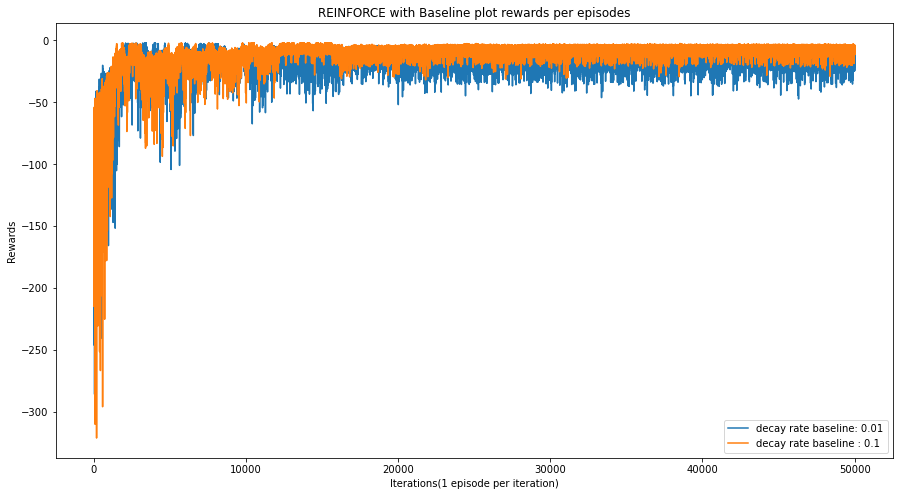

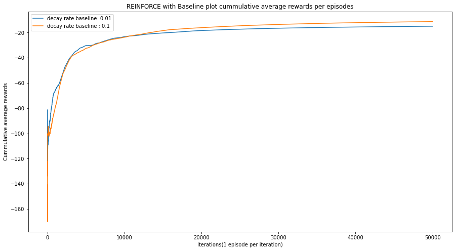

```python
_ = plt.figure(figsize = (15,8))
_ = tuning_baseline_dict['result'][0]['train_rewards'].plot(label = 'decay rate baseline: %s'%(tuning_baseline_dict['decayRateW'][0]))
_ = tuning_baseline_dict['result'][1]['train_rewards'].plot(label = 'decay rate baseline : %s'%(tuning_baseline_dict['decayRateW'][1]))
_ = plt.legend()
_ = plt.title('REINFORCE with Baseline plot rewards per episodes')
_ = plt.xlabel('Iterations(1 episode per iteration)')
_ = plt.ylabel('Rewards')

_ = plt.figure(figsize = (15,8))
_ = tuning_baseline_dict['result'][0]['cummulative_train_rewards'].plot(label = 'decay rate baseline: %s'%(tuning_baseline_dict['decayRateW'][0]))
_ = tuning_baseline_dict['result'][1]['cummulative_train_rewards'].plot(label = 'decay rate baseline : %s'%(tuning_baseline_dict['decayRateW'][1]))
_ = plt.legend()
_ = plt.title('REINFORCE with Baseline plot cummulative average rewards per episodes')
_ = plt.xlabel('Iterations(1 episode per iteration)')
_ = plt.ylabel('Cummulative average rewards')
```

##### We choose decay rate from initial learning rate of linear baselinear = 0.1 for comparison and saved to csv.

- The two learning rates used for parameters tunning can accelerate learning at the same rate.
- However, we can observe that the higher the learning rate decay, the less volatile the Rewards per iterations are.

```python
tuning_baseline_dict['result'][0].to_csv('REINFORCEwithBaseline_LRw0.01.csv')
tuning_baseline_dict['result'][1].to_csv('REINFORCEwithBaseline_LRw0.1.csv')
```